# act_report

## WeRateDogs: act_report

### Introduction

WeRateDogs is an awesome Twitter page that rates people's dogs with a humorous comment about the dog. Usually, the ratings are above normal scale of 10 and can even be higher than 15.

According to the founder, Matt Nelson, WeRateDogs community is on a mission to celebrate good dogs (they’re all good dogs) by sharing their stories, improving their lives, and helping the ones who need us most.

[figure not shown]

### Analysis Processes

Three different data on WeRateDogs were gathered using the necessary libraries, assessed manually and programmatically, cleaned both the dirty and messy data, and analyzed statistically and visually. One of the data used was gotten by querying Twitter API.

This project majorly involve data wrangling. During the cleaning process, the quality and tidiness issues in the data were carefully observed and properly dealt with. After these processes, the insights below were generated from statistical summary and graphical visualization of WeRateDogs data.

### 1. Statistical Distribution of WeRateDog Data

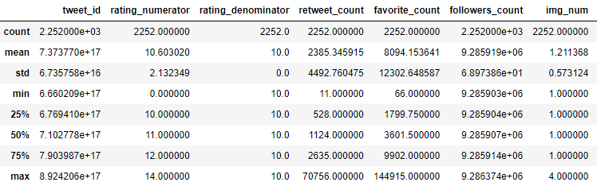

### 2. Most Frequent Dog Stage

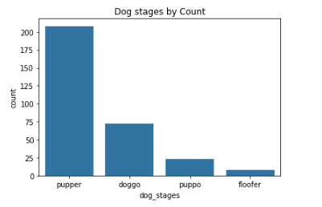

- Pupper happens to be the most frequent dog tweeted on WeRateDogs followed by Doggo, then Puppo, while Floofer is the least.

### 3. Ratings between Pupper and Floofer

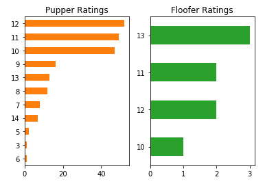

- Most of Pupper dogs are rated above 9 with the highest rating being 14 and the least being 3.
- For Floofer, there are just 4 unique ratings from 10 to 13 with 13 having the most counts.

### 4. Relationship between Ratings and People's Engagement

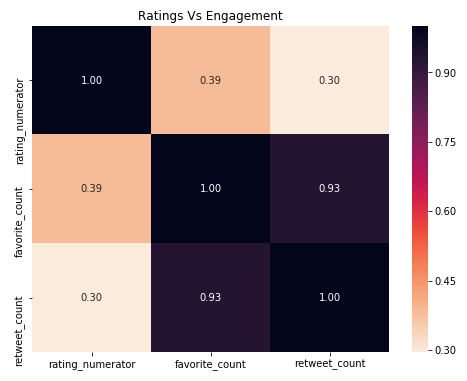

- There is almost a perfect correlation (0.93) between favorite_count and retweet_count indicating that as tweeps retweet, they also tend to like the tweets.
- However, there is a weak relationship between ratings and people's engagement (0.39 for favorite_count and 0.30 for retweet_count). This means that a tweet having higher rating doesn't translate to having higher retweets or likes.

[figure not shown]